# Data 605 HW11: Regression Analysis in R 1

# 1 Regression Problem

Using the “cars” dataset in R, build a linear model for stopping distance as a function of speed and replicate the analysis of your textbook chapter 3 (visualization, quality evaluation of the model, and residual analysis.)

## 1.1 Import Data

There are 50 observations of speed of cars and the distances taken to stop from the dataset `cars` without any NA values.

```r
data <- datasets::cars
head(cars)
```

|  | speed | dist |
| --- | --- | --- |
| 1 | 4 | 2 |
| 2 | 4 | 10 |
| 3 | 7 | 4 |
| 4 | 7 | 22 |
| 5 | 8 | 16 |
| 6 | 9 | 10 |

```r
summary(cars)
```

```
##      speed           dist
##  Min.   : 4.0   Min.   :  2.00
##  1st Qu.:12.0   1st Qu.: 26.00
##  Median :15.0   Median : 36.00
##  Mean   :15.4   Mean   : 42.98
##  3rd Qu.:19.0   3rd Qu.: 56.00
##  Max.   :25.0   Max.   :120.00
```

```r
dim(data)
```

```
## [1] 50  2
```

## 1.2 Visualize the Data

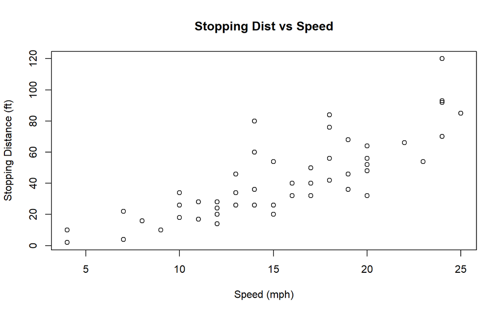

```r
plot(data, main = "Stopping Dist vs Speed", xlab = "Speed (mph)", ylab = "Stopping Distance (ft)")
```

## 1.3 Build a Linear Model

Build a simple linear model with the dataset `cars`.

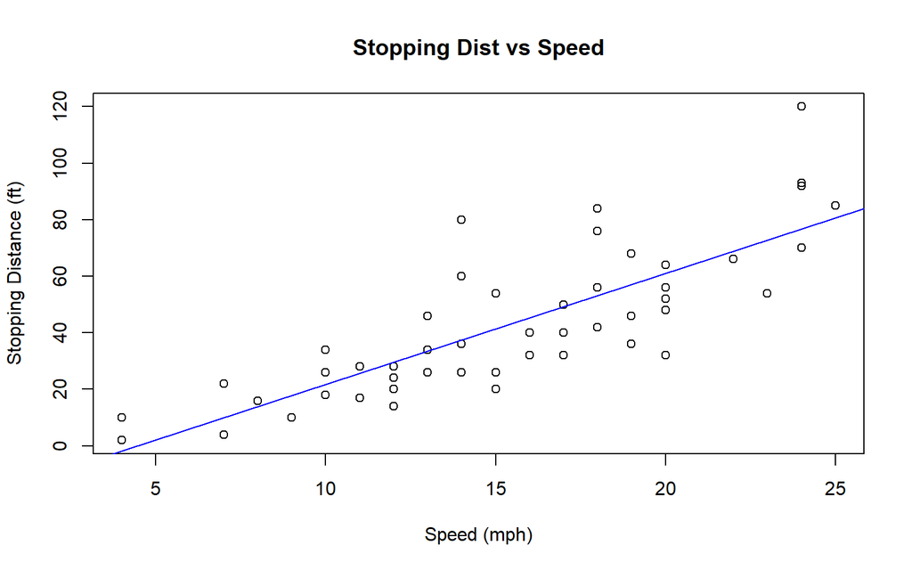

```r
cars_lm <- lm(dist~speed, data=cars)
plot(data, main = "Stopping Dist vs Speed", xlab = "Speed (mph)", ylab = "Stopping Distance (ft)")
abline(reg=cars_lm, col="blue")
```

## 1.4 Evaluate the Model

Quality evaluation of the model:

Residuals: the median is close to zero and the 1Q vs 3Q and min vs max are roughly the same magnitude. This shows that the model is a fairly good model.

P-value: The p-value of speed is very close to zero, which shows a strong significance at 99% confidence, while the intercept is significant at 95% confidence. This shows that the model is predicting the two values quite well.

Multiple R-squared: The $R^{2}$ value represents how well the model describes the measured data. It explains 65.11% of the data’s variation, which is fairly good.

```r
summary(cars_lm)
```

```
##
## Call:
## lm(formula = dist ~ speed, data = cars)
##
## Residuals:
##     Min      1Q  Median      3Q     Max
## -29.069  -9.525  -2.272   9.215  43.201
##
## Coefficients:
##             Estimate Std. Error t value Pr(>|t|)
## (Intercept) -17.5791     6.7584  -2.601   0.0123 *
## speed         3.9324     0.4155   9.464 1.49e-12 ***
## ---
## Signif. codes:  0 '***' 0.001 '**' 0.01 '*' 0.05 '.' 0.1 ' ' 1
##
## Residual standard error: 15.38 on 48 degrees of freedom
## Multiple R-squared:  0.6511, Adjusted R-squared:  0.6438
## F-statistic: 89.57 on 1 and 48 DF,  p-value: 1.49e-12
```

## 1.5 Residual Analysis

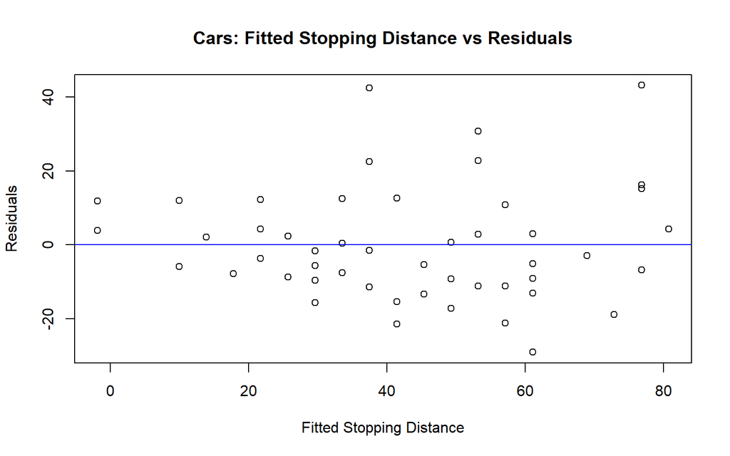

```r
plot(fitted(cars_lm), resid(cars_lm),
     main = "Cars: Fitted Stopping Distance vs Residuals",
     xlab = "Fitted Stopping Distance", ylab = "Residuals")
abline(h=0, col="blue")
```

The QQ plot shows some outliers above the line at the upper end and the lower end. The residuals might not be very normal.

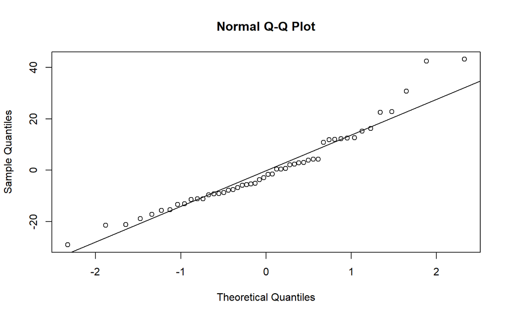

```r
qqnorm(resid(cars_lm))
qqline(resid(cars_lm))
```

To check the normality, we can also look at the histogram or a normal probability plot of the residuals.

The histogram is bimodal and slightly right-skewed. Therefore, the residuals are barely normal.

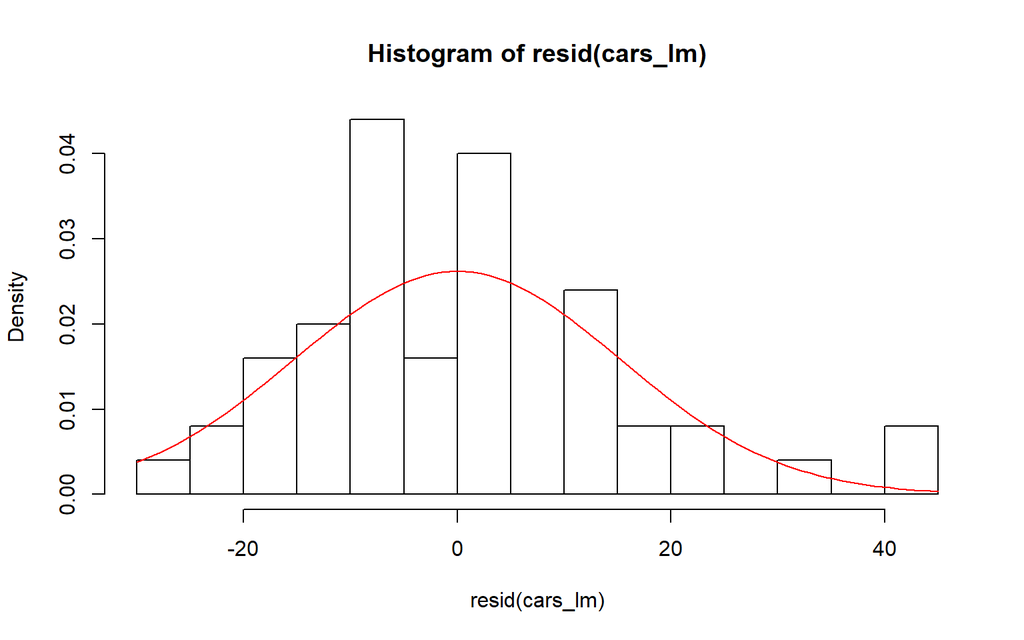

```r
hist(resid(cars_lm), breaks=15, prob=TRUE)
curve(dnorm(x, mean=mean(resid(cars_lm)), sd=sd(resid(cars_lm))), col="red", add=TRUE)
```